# ICC4 - Manhattan plots

Joëlle Pasman

November 19, 2025

# Mirror plot ever use

We start with a mirror Manhattan plot (Miami plot) for the trans-ancestry and European results for ever use of cannabis.

## Europeans

The summary statistics are formatted and top SNPs are identified using clumping. For the X-chromosome, the risk loci were filtered out because they were not present in the reference data. We added them and manually clumped them based on proximity. Note that loci that were too close to each other were pruned further (even if they were genome-wide significant) for visibility.

```r
CANNABIS_EVR <- fread("metal/MA_CANNABIS_EVR_250919.txt.gz")
CANNABIS_EVR_X <- fread("metal/MA_CANNABIS_EVR_X_250409.txt")
CANNABIS_EVR <- rbind(CANNABIS_EVR, CANNABIS_EVR_X) %>%
  mutate(CHR = ifelse(CHR == "X", 23, CHR),
         CHR = as.numeric(CHR))

CANNABIS_EVR_cum <- CANNABIS_EVR %>%
  group_by(CHR) %>%
  summarise(max_bp = max(BP)) %>%
  mutate(bp_add = lag(cumsum(as.numeric(max_bp)), default = 0)) %>%
  select(CHR, bp_add)

CANNABIS_EVR_data <- CANNABIS_EVR %>%
  inner_join(CANNABIS_EVR_cum, by = "CHR") %>%
  mutate(bp_cum = BP + bp_add) %>%
  mutate(uniqID = paste(CHR, BP, A1, A2, sep = ":"))

axis_set <- CANNABIS_EVR_data %>%
  group_by(CHR) %>%
  summarize(center = mean(bp_cum))

ylim <- CANNABIS_EVR_data %>%
  filter(P == min(P)) %>%
  mutate(ylim = -1 * abs(floor(log10(P)))) %>%
  pull(ylim)

ylim <- ylim - 2

sig <- 5e-8

# Clump hits

CANNABIS_top <- CANNABIS_EVR %>%
  filter(P<5e-8) %>%
  rename(effect_allele = A1) %>%
  rename(other_allele = A2) %>%
  rename(eaf=EAF) %>%
  rename(beta=BETA) %>%
  rename(se=SE) %>%
  rename(pval=P) %>%
  rename(samplesize=N)

fwrite(CANNABIS_top, "metal/CANNABIS_EVR.hits", sep=" ", quote=F, na=NA)

CANNABIS_top <- read_exposure_data("metal/CANNABIS_EVR.hits")
CANNABIS_top <- clump_data(
  CANNABIS_top,
  clump_kb = 10000,
  clump_r2 = 0.01,
  bfile = "/1000genomes/1kg.v3/EUR",
  plink_bin = "/genetics.binaRies/bin/plink"
)

CANNABIS_top <- CANNABIS_top %>%
  select(SNP) %>%
  left_join(CANNABIS_EVR_data)

CANNABIS_top_nonoverlapping <- CANNABIS_top %>%
  arrange(P) %>%
  group_by(CHR) %>%
  do({
    snps <- .
    kept <- c()
    for (i in seq_len(nrow(snps))) {
      pos <- snps$bp_cum[i]
      if (all(abs(pos - snps$bp_cum[kept]) > 15000000)) {
        kept <- c(kept, i)
      }
    }
    snps[kept, ]
  }) %>%
  ungroup()

# SNPs that overlap with other labels after ggrepel are plotted separately
CANNABIS_top_nonoverlapping <- CANNABIS_top_nonoverlapping %>% filter(SNP != "rs62389423" & SNP != "rs4856598" & SNP != "rs113367058" & SNP != "rs1061808")


## X SNPs are not in clump reference file so add those manually

CANNABIS_top_X <- CANNABIS_EVR_data %>%
  filter(CHR == 23 & P<5e-8)

CANNABIS_top_X$bp_bin <- cut(
  CANNABIS_top_X$bp_cum,
  breaks = quantile(CANNABIS_top_X$bp_cum, probs = seq(0, 1, length.out = 10), na.rm = TRUE),
  include.lowest = TRUE,
  labels = FALSE
)

CANNABIS_top_X <- CANNABIS_top_X %>%
  filter(bp_bin == 1 | bp_bin == 9) %>%
  group_by(bp_bin) %>%
  arrange(P) %>%
  slice(1)



# Add genes mapped positionally with FUMA

CANNABIS_EVR_genes <- fread("fuma/CANNABIS_EVR_genes.txt")

CANNABIS_EVR_genes_cum <- CANNABIS_EVR_genes %>%
  rename(CHR = chr) %>%
  filter(minGwasP <5e-8) %>%
  mutate(mid = end - ((end - start)/2)) %>%
  left_join(CANNABIS_EVR_cum, by = "CHR") %>%
  mutate(bp_cum = mid + bp_add)

## group loci that are close
threshold <- 10000000

CANNABIS_EVR_genes_top <- CANNABIS_EVR_genes_cum %>%
  group_by(CHR) %>%
  arrange(bp_cum) %>%
  mutate(
    Group = cumsum(ifelse(is.na(lag(bp_cum)) | (bp_cum - lag(bp_cum) > threshold), 1, 0))
  ) %>%
  group_by(CHR, Group) %>%
  arrange(minGwasP, .by_group = T) %>%
  slice(1) %>%
  ungroup()

# make some lines for exact gene position

dashedlines <- CANNABIS_EVR_genes_cum %>%
  select(bp_cum)

x_coordinates <- eval(parse(text = as.character(dashedlines)))
```

Then the plot is drawn and annotated:

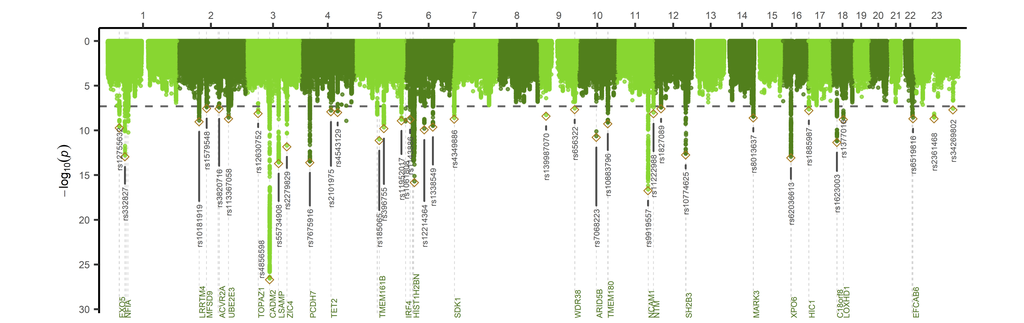

```r
png("metal/CANNABIS_EVR_eur_manh.png", width=190, height=60, units="mm", res=1000)
ggplot(CANNABIS_EVR_data, aes(x = bp_cum, y = log10(P), color = as_factor(CHR), size = log10(P))) +

  geom_hline(yintercept = log10(sig), color = "grey40", linetype = "dashed", linewidth = 0.5) +
  geom_vline(xintercept = x_coordinates, linetype = "dashed", color = "lightgrey", linewidth = 0.2) +

  geom_point(alpha = 0.75, size = 0.5) +
  scale_x_continuous(label = axis_set$CHR,
                     breaks = axis_set$center,
                     position = "top",
                     expand = expansion(mult = c(0.01, 0.01))) +
  coord_cartesian(ylim = c(ylim, 0),
                  clip = "off") +
  scale_y_continuous(
    breaks = pretty(c(ylim, 0)),
    labels = function(b) abs(b)
  ) +
  scale_color_manual(values = rep(c("#88d631", "#517f1c"), length(unique(axis_set$CHR)))) +
  scale_size_continuous(range = c(0.5,3)) +
  labs(x = NULL,
       y = bquote(-log[10](italic(p)))) +

  theme_classic() +
  theme(
    legend.position = "none",
    panel.grid.major.x = element_blank(),
    panel.grid.minor.x = element_blank(),
    axis.text.x = element_text(vjust = 0.5),
    text = element_text(size = 6.5),
    plot.margin = margin(5, 30, 5, 30)
  ) +

  geom_text(data=CANNABIS_top_nonoverlapping,
            aes(x=bp_cum, y = log10(P)),
            label = "\U25C7",
            color="#a6761d",
            size = 3
  ) +

  geom_text_repel(
    data = CANNABIS_top_nonoverlapping,
    aes(x = bp_cum, y = log10(P) - 1, label = SNP),
    color = "grey30",
    size = 1.5,
    angle = 90,
    direction = "y",
    hjust = 1,
    box.padding = 0.3,
    point.padding = 0.3,
    force = 2,
    max.overlaps = Inf,
    ylim = c(ylim+5, 0),
    min.segment.length = 0
  ) +

  geom_text(
    data = CANNABIS_EVR_genes_top,
    aes(x = bp_cum, y = ylim-2, label = symbol),
    color = "#476f19",
    size = 1.5,
    angle = 90,
    vjust = 1,
    hjust = 0
  ) +

  geom_text(data=subset(CANNABIS_top, SNP == "rs1061808"),
            aes(x = bp_cum - 30000000, y = log10(P)-2, label = SNP),
            color = "grey30",
            size = 1.5,
            angle = 90,
            hjust = 0
            ) +

  geom_text(data=subset(CANNABIS_top, SNP == "rs1061808"),
            aes(x=bp_cum, y = log10(P)),
            label = "\U25C7",
            color="#a6761d",
            size = 3
  ) +

  geom_text(data=subset(CANNABIS_top, SNP == "rs4856598"),
            aes(x = bp_cum - 30000000, y = log10(P), label = SNP),
            color = "grey30",
            size = 1.5,
            angle = 90,
            hjust = 0
  ) +

  geom_text(data=subset(CANNABIS_top, SNP == "rs4856598"),
            aes(x=bp_cum, y = log10(P)),
            label = "\U25C7",
            color="#a6761d",
            size = 3
  ) +

  geom_text(data=subset(CANNABIS_top, SNP == "rs113367058"),
            aes(x = bp_cum, y = log10(P) - 11, label = SNP),
            color = "grey30",
            size = 1.5,
            angle = 90,
            hjust = 0
  ) +

  geom_text(data=subset(CANNABIS_top, SNP == "rs113367058"),
            aes(x=bp_cum, y = log10(P)),
            label = "\U25C7",
            color="#a6761d",
            size = 3
  ) +

  geom_text(data=CANNABIS_top_X,
            aes(x = bp_cum, y = log10(P) - 6, label = SNP),
            color = "grey30",
            size = 1.5,
            angle = 90,
            hjust = 0) +

  geom_text(data=CANNABIS_top_X,
            aes(x=bp_cum, y = log10(P)),
            label = "\U25C7",
            color="#a6761d",
            size = 3
  )

dev.off()

fwrite(CANNABIS_top, "metal/CANNABIS_EVR_eur_tophits.csv")
fwrite(CANNABIS_top_X, "metal/CANNABIS_EVR_eur_topX.csv")
```

## Trans-ancestry

Now prepare the dataframe for the trans-ancestry results in the same manner. There were no hits on chromosome X for this analysis.

```r
### Trans ancestry

CANNABIS_EVR <- fread("metal/MA_CANNABIS_EVR_cross_250919.txt.gz")

CANNABIS_EVR_cum <- CANNABIS_EVR %>%
  mutate(CHR = ifelse(CHR == "X", 23, CHR)) %>%
  mutate(CHR = as.numeric(CHR)) %>%
  group_by(CHR) %>%
  summarise(max_bp = max(BP)) %>%
  mutate(bp_add = lag(cumsum(as.numeric(max_bp)), default = 0)) %>%
  select(CHR, bp_add)

CANNABIS_EVR_data <- CANNABIS_EVR %>%
  mutate(CHR = ifelse(CHR == "X", 23, CHR)) %>%
  mutate(CHR = as.numeric(CHR)) %>%
  inner_join(CANNABIS_EVR_cum, by = "CHR") %>%
  mutate(bp_cum = BP + bp_add) %>%
  mutate(uniqID = paste(CHR, BP, A1, A2, sep = ":"))

axis_set <- CANNABIS_EVR_data %>%
  group_by(CHR) %>%
  summarize(center = mean(bp_cum))

ylim <- CANNABIS_EVR_data %>%
  filter(P == min(P)) %>%
  mutate(ylim = abs(floor(log10(P))) + 10.5) %>%
  pull(ylim)

ylim <- 30

sig <- 5e-8

# Use hits clumped with FUMA

CANNABIS_top <- fread("fuma/CANNABIS_EVR_cross_riskloci.txt")

CANNABIS_top <- CANNABIS_top %>%
  rename(SNP = rsID) %>%
  select(SNP) %>%
  left_join(CANNABIS_EVR_data)

CANNABIS_top_nonoverlapping <- CANNABIS_top %>%
  arrange(P) %>%
  group_by(CHR) %>%
  do({
    snps <- .
    kept <- c()
    for (i in seq_len(nrow(snps))) {
      pos <- snps$bp_cum[i]
      if (all(abs(pos - snps$bp_cum[kept]) > 15000000)) {
        kept <- c(kept, i)
      }
    }
    snps[kept, ]
  }) %>%
  ungroup()

# SNPs that overlap with other labels after ggrepel are plotted separately
CANNABIS_top_nonoverlapping <- CANNABIS_top_nonoverlapping %>% filter(SNP != "rs34676049" & SNP != "rs956281")


# Add genes mapped positionally with FUMA

CANNABIS_EVR_genes <- fread("fuma/CANNABIS_EVR_cross_genes.txt")

CANNABIS_EVR_genes_cum <- CANNABIS_EVR_genes %>%
  rename(CHR = chr) %>%
  filter(minGwasP <5e-8) %>%
  mutate(mid = end - ((end - start)/2)) %>%
  left_join(CANNABIS_EVR_cum, by = "CHR") %>%
  mutate(bp_cum = mid + bp_add)

## group loci that are close
threshold <- 10000000

CANNABIS_EVR_genes_top <- CANNABIS_EVR_genes_cum %>%
  group_by(CHR) %>%
  arrange(bp_cum) %>%
  mutate(
    Group = cumsum(ifelse(is.na(lag(bp_cum)) | (bp_cum - lag(bp_cum) > threshold), 1, 0))
  ) %>%
  group_by(CHR, Group) %>%
  arrange(minGwasP, .by_group = T) %>%
  slice(1) %>%
  ungroup()





# make some lines for exact gene position

dashedlines <- CANNABIS_EVR_genes_cum %>%
  select(bp_cum)

x_coordinates <- eval(parse(text = as.character(dashedlines)))
```

Transancestry plot ever use:

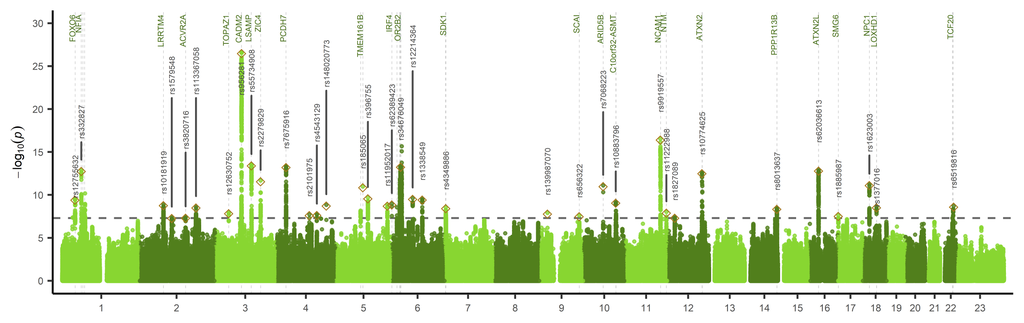

```r
png("metal/CANNABIS_EVR_cross_manh.png", width=190, height=60, units="mm", res=1000)
ggplot(CANNABIS_EVR_data, aes(x = bp_cum, y = -log10(P), color = as_factor(CHR), size = -log10(P))) +

  geom_hline(yintercept = -log10(sig), color = "grey40", linetype = "dashed", linewidth = 0.5) +
  geom_vline(xintercept = x_coordinates, linetype = "dashed", color = "lightgrey", linewidth = 0.2) +

  geom_point(alpha = 0.75, size = 0.5) +
  scale_x_continuous(label = axis_set$CHR,
                     breaks = axis_set$center,
                     expand = expansion(mult = c(0.01, 0.01))) +
  coord_cartesian(ylim = c(0, ylim),
                  clip = "off") +
  scale_y_continuous(
    breaks = pretty(c(ylim, 0)),
    labels = function(b) abs(b)
  ) +
  scale_color_manual(values = rep(c("#88d631", "#517f1c"), unique(length(axis_set$CHR)))) +
  scale_size_continuous(range = c(0.5,3)) +
  labs(x = NULL,
       y = bquote(-log[10](italic(p)))) +

  theme_classic() +
  theme(
    legend.position = "none",
    panel.grid.major.x = element_blank(),
    panel.grid.minor.x = element_blank(),
    axis.text.x = element_text(vjust = 0.5),
    text = element_text(size = 6.5)
  ) +

  geom_text(data=CANNABIS_top_nonoverlapping,
            aes(x=bp_cum, y = -log10(P)),
            label = "\U25C7",
            # label = "\U0001F341",
            color="#a6761d",
            size = 3
  ) +

  geom_text_repel(
    data = CANNABIS_top_nonoverlapping,
    aes(x = bp_cum, y = -log10(P) + 1, label = SNP),
    color = "grey30",
    size = 1.5,
    angle = 90,
    direction = "y",
    hjust = 0,
    box.padding = 0.3,
    point.padding = 0.3,
    force = 2,
    max.overlaps = Inf
  ) +

  geom_text(
    data = CANNABIS_EVR_genes_top,
    aes(x = bp_cum, y = ylim + 1, label = symbol),
    color = "#476f19",
    size = 1.5,
    angle = 90,
    vjust = 0,
    hjust = 1
  ) +

  geom_text(data=subset(CANNABIS_top, SNP == "rs34676049"),
            aes(x = bp_cum, y = -log10(P) + 3, label = SNP),
            color = "grey30",
            size = 1.5,
            angle = 90,
            hjust = 0
  ) +

  geom_text(data=subset(CANNABIS_top, SNP == "rs34676049"),
            aes(x=bp_cum, y = -log10(P)),
            label = "\U25C7",
            color="#a6761d",
            size = 3
  ) +

  geom_text(data=subset(CANNABIS_top, SNP == "rs956281"),
            aes(x = bp_cum -1000000, y = -log10(P) - 5, label = SNP),
            color = "grey30",
            size = 1.5,
            angle = 90,
            hjust = 0
  ) +

  geom_text(data=subset(CANNABIS_top, SNP == "rs956281"),
            aes(x=bp_cum, y = -log10(P)),
            label = "\U25C7",
            color="#a6761d",
            size = 3
  )
dev.off()

fwrite(CANNABIS_top, "metal/CANNABIS_EVR_cross_tophits.csv")
```

# Combined frequency

For the Europeans, we combined the frequency summary statistics with Genomic SEM and ran a GWAS on this all-frequency phenotype. We follow the same procedure as before to prepare and plot the results.

```r
frq <- fread("gsem/MA_FREQ_ALL_250919.txt.gz")

frq_cum <- frq %>%
  group_by(CHR) %>%
  summarise(max_bp = max(BP)) %>%
  mutate(bp_add = lag(cumsum(as.numeric(max_bp)), default = 0)) %>%
  select(CHR, bp_add)

frq_data <- frq %>%
  inner_join(frq_cum, by = "CHR") %>%
  mutate(bp_cum = BP + bp_add) %>%
  mutate(uniqID = paste(CHR, BP, A1, A2, sep = ":"))

axis_set <- frq_data %>%
  group_by(CHR) %>%
  summarize(center = mean(bp_cum))

ylim <- frq_data %>%
  filter(P == min(P)) %>%
  mutate(ylim = abs(floor(log10(P))) + 5.5) %>%
  pull(ylim)


sig <- 5e-8

# Clump hits

frq_top <- frq %>%
  filter(P<5e-8) %>%
  rename(effect_allele = A1) %>%
  rename(other_allele = A2) %>%
  rename(eaf=EAF) %>%
  rename(beta=BETA) %>%
  rename(se=SE) %>%
  rename(pval=P) %>%
  rename(samplesize=N)

fwrite(frq_top, "gsem/FREQ_MA.hits", sep=" ", quote=F, na=NA)
frq_top <- read_exposure_data("gsem/FREQ_MA.hits")
frq_top <- clump_data(
  frq_top,
  clump_kb = 10000,
  clump_r2 = 0.01,
  bfile = "C:/Users/P018906/OneDrive - Amsterdam UMC/Documents/AMC bridge/1000genomes/1kg.v3/EUR",
  plink_bin = "C:/Users/P018906/AppData/Local/R/win-library/4.3/genetics.binaRies/bin/plink"
)

frq_top <- frq_top %>%
  select(SNP) %>%
  left_join(frq_data)

# Create df for genes

frq_genes <- fread("fuma/FREQ_MA_genes.txt")

frq_genes_cum <- frq_genes %>%
  rename(CHR = chr) %>%
  filter(minGwasP <5e-8) %>%
  mutate(mid = end - ((end - start)/2)) %>%
  left_join(CANNABIS_EVR_cum, by = "CHR") %>%
  mutate(bp_cum = mid + bp_add)


## group genes that are close
threshold <- 10000000

frq_genes_top <- frq_genes_cum %>%
  group_by(CHR) %>%
  arrange(bp_cum) %>%
  mutate(
    Group = cumsum(ifelse(is.na(lag(bp_cum)) | (bp_cum - lag(bp_cum) > threshold), 1, 0))
  ) %>%
  group_by(CHR, Group) %>%
  arrange(minGwasP, .by_group = T) %>%
  slice(1) %>%
  ungroup()

## Keep lines for all genes
dashedlines <- frq_genes_cum %>%
  select(bp_cum)

x_coordinates <- eval(parse(text = as.character(dashedlines)))
```

All frequency plot Europeans:

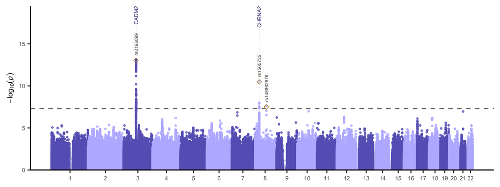

```r
png("gsem/FREQ_MA_manh.png", width=160, height=60, units="mm", res=1000)
ggplot(frq_data, aes(x = bp_cum, y = -log10(P), color = as_factor(CHR), size = -log10(P))) +

  geom_hline(yintercept = -log10(sig), color = "grey40", linetype = "dashed", linewidth = 0.5) +
  geom_vline(xintercept = x_coordinates, linetype = "dashed", color = "lightgrey", linewidth = 0.2) +

  geom_point(alpha = 0.75, size = 0.5) +
  scale_x_continuous(label = axis_set$CHR, breaks = axis_set$center) +
  scale_y_continuous(expand = c(0,0), limits = c(0, ylim)) +
  scale_color_manual(values = rep(c("#544cb2", "#aea7ff"), unique(length(axis_set$CHR)))) +
  scale_size_continuous(range = c(0.5,3)) +
  labs(x = NULL,
       y = bquote(-log[10](italic(p)))) +

  theme_classic() +
  theme(
    legend.position = "none",
    panel.grid.major.x = element_blank(),
    panel.grid.minor.x = element_blank(),
    axis.text.x = element_text(vjust = 0.5),
    text = element_text(size = 6.5)
  ) +

  geom_text(data=frq_top,
            aes(x=bp_cum, y = -log10(P)),
            label = "\U25C7",
            color="#a6761d",
            size = 3
  ) +

  geom_text(data=frq_top,
                  aes(x=bp_cum, y = -log10(P) + 0.5, label = SNP),
                  color="grey30",
                  size = 1.5,
                  angle = 90,
                  hjust = 0
  ) +

  geom_text(data=frq_genes_top,
            aes(x = bp_cum, y = ylim, label=symbol),
            color="#383278",
            bg = "rgba(255,255,255,0.5)",
            size = 1.7,
            angle = 90,
            vjust = 0.5,
            hjust = 1)

dev.off()
```

# All cannabis factor

We also ran a GWAS on a Genomic SEM model combining the frequency and ever use traits. It had many hits and required much pruning for displaying.

```r
factor <- fread("gsem/MA_CANN_FACTOR_250919.txt.gz")

factor_cum <- factor %>%
  group_by(CHR) %>%
  summarise(max_bp = max(BP)) %>%
  mutate(bp_add = lag(cumsum(as.numeric(max_bp)), default = 0)) %>%
  select(CHR, bp_add)

factor_data <- factor %>%
  inner_join(factor_cum, by = "CHR") %>%
  mutate(bp_cum = BP + bp_add) %>%
  mutate(uniqID = paste(CHR, BP, A1, A2, sep = ":"))

axis_set <- factor_data %>%
  group_by(CHR) %>%
  summarize(center = mean(bp_cum))

ylim <- factor_data %>%
  filter(P == min(P)) %>%
  mutate(ylim = abs(floor(log10(P))) + 5.5) %>%
  pull(ylim)


sig <- 5e-8

# Clump hits

factor_top <- factor %>%
  filter(P<5e-8) %>%
  rename(effect_allele = A1) %>%
  rename(other_allele = A2) %>%
  rename(eaf=EAF) %>%
  rename(beta=BETA) %>%
  rename(se=SE) %>%
  rename(pval=P) %>%
  rename(samplesize=N)

fwrite(factor_top, "gsem/CANNABIS_FACTOR.hits", sep=" ", quote=F, na=NA)
factor_top <- read_exposure_data("gsem/CANNABIS_FACTOR.hits")
factor_top <- clump_data(
  factor_top,
  clump_kb = 10000,
  clump_r2 = 0.01,
  bfile = "C:/Users/P018906/OneDrive - Amsterdam UMC/Documents/AMC bridge/1000genomes/1kg.v3/EUR",
  plink_bin = "C:/Users/P018906/AppData/Local/R/win-library/4.3/genetics.binaRies/bin/plink"
)

factor_top <- factor_top %>%
  select(SNP) %>%
  left_join(factor_data)

factor_top_nonoverlapping <- factor_top %>%
  arrange(P) %>%
  group_by(CHR) %>%
  do({
    snps <- .
    kept <- c()
    for (i in seq_len(nrow(snps))) {
      pos <- snps$bp_cum[i]
      if (all(abs(pos - snps$bp_cum[kept]) > 15000000)) {
        kept <- c(kept, i)
      }
    }
    snps[kept, ]
  }) %>%
  ungroup()

factor_top_nonoverlapping <- factor_top_nonoverlapping %>% filter(SNP != "rs62389424" & SNP != "rs34495106")


# Create df for mapped genes

factor_genes <- fread("fuma/CANNABIS_FACTOR_genes.txt")

factor_genes_cum <- factor_genes %>%
  rename(CHR = chr) %>%
  filter(minGwasP <5e-8) %>%
  mutate(mid = end - ((end - start)/2)) %>%
  left_join(factor_cum, by = "CHR") %>%
  mutate(bp_cum = mid + bp_add)

## group loci that are close
threshold <- 20000000

factor_genes_top <- factor_genes_cum %>%
  group_by(CHR) %>%
  arrange(bp_cum) %>%
  mutate(
    Group = cumsum(ifelse(is.na(lag(bp_cum)) | (bp_cum - lag(bp_cum) > threshold), 1, 0))
  ) %>%
  group_by(CHR, Group) %>%
  arrange(minGwasP, .by_group = T) %>%
  slice(1) %>%
  ungroup()

dashedlines <- factor_genes_cum %>%
  select(bp_cum)

x_coordinates <- eval(parse(text = as.character(dashedlines)))
```

All cannabis plot Europeans:

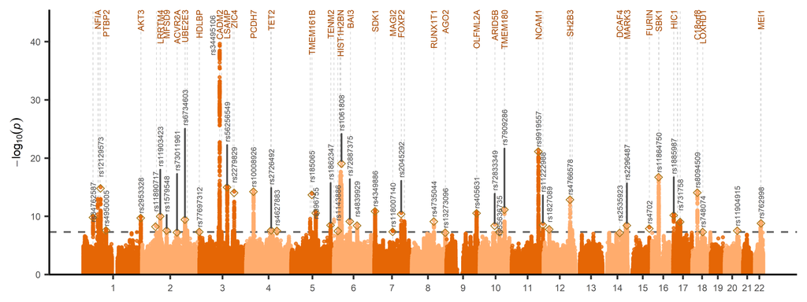

```r
png("gsem/CANNABIS_FACTOR_manh.png", width=160, height=60, units="mm", res=1000)
ggplot(factor_data, aes(x = bp_cum, y = -log10(P), color = as_factor(CHR), size = -log10(P))) +

  geom_hline(yintercept = -log10(sig), color = "grey40", linetype = "dashed", linewidth = 0.5) +
  geom_vline(xintercept = x_coordinates, linetype = "dashed", color = "lightgrey", linewidth = 0.2) +

  geom_point(alpha = 0.75, size = 0.5) +
  scale_x_continuous(label = axis_set$CHR, breaks = axis_set$center) +
  scale_y_continuous(expand = c(0,0), limits = c(0, ylim)) +
  scale_color_manual(values = rep(c("#e56605", "#ffac6d"), unique(length(axis_set$CHR)))) +
  scale_size_continuous(range = c(0.5,3)) +
  labs(x = NULL,
       y = bquote(-log[10](italic(p)))) +

  theme_classic() +
  theme(
    legend.position = "none",
    panel.grid.major.x = element_blank(),
    panel.grid.minor.x = element_blank(),
    axis.text.x = element_text(vjust = 0.5),
    text = element_text(size = 6.5)
  ) +

  geom_text(data=factor_top_nonoverlapping,
            aes(x=bp_cum, y = -log10(P)),
            label = "\U25C7",
            color="#a6761d",
            size = 3
  ) +

  geom_text(data=subset(factor_top, SNP == "rs34495106"),
            aes(x = bp_cum - 30000000, y = -log10(P)-2, label = SNP),
            color = "grey30",
            size = 1.5,
            angle = 90,
            hjust = 0
  ) +

  geom_text_repel(data=factor_top_nonoverlapping,
                  aes(x=bp_cum, y = -log10(P), label = SNP),
                  color="grey30",
                  size = 1.5,
                  angle = 90,
                  direction = "y",
                  hjust = 0,
                  box.padding = 0.1,
                  point.padding = 0.1
  ) +


  geom_text(data=factor_genes_top,
            aes(x = bp_cum, y = ylim, label=symbol),
            color="#a84a02",
            bg = "rgba(255,255,255,0.5)",
            size = 1.7,
            angle = 90,
            vjust = 0.5,
            hjust = 1)

dev.off()
```

# Separate frequency traits

For the supplementary figures, we now move on to per frequency trait Manhattan plots.

## Frequency lifetime

Total number of times someone has used cannabis in their life (European only).

```r
frq_life <- fread("metal/MA_FREQ_LIFETIME_250919.txt.gz")
frq_life_X <- fread("metal/MA_FREQ_LIFETIME_X_250409.txt")

frq_life <- rbind(frq_life, frq_life_X) %>%
  mutate(CHR = ifelse(CHR == "X", 23, CHR),
         CHR = as.numeric(CHR))

frq_life_cum <- frq_life %>%
  group_by(CHR) %>%
  summarise(max_bp = max(BP)) %>%
  mutate(bp_add = lag(cumsum(as.numeric(max_bp)), default = 0)) %>%
  select(CHR, bp_add)

frq_life_data <- frq_life %>%
  inner_join(frq_life_cum, by = "CHR") %>%
  mutate(bp_cum = BP + bp_add) %>%
  mutate(uniqID = paste(CHR, BP, A1, A2, sep = ":"))

axis_set <- frq_life_data %>%
  group_by(CHR) %>%
  summarize(center = mean(bp_cum))

ylim <- frq_life_data %>%
  filter(P == min(P)) %>%
  mutate(ylim = abs(floor(log10(P))) + 10.5) %>%
  pull(ylim)

sig <- 5e-8



# Clump hits

frq_life_top <- frq_life %>%
  filter(P<5e-8) %>%
  rename(effect_allele = A1) %>%
  rename(other_allele = A2) %>%
  rename(eaf=EAF) %>%
  rename(beta=BETA) %>%
  rename(se=SE) %>%
  rename(pval=P) %>%
  rename(samplesize=N)

fwrite(frq_life_top, "metal/FREQ_LIFETIME.hits", sep=" ", quote=F, na=NA)
frq_life_top <- read_exposure_data("metal/FREQ_LIFETIME.hits")
frq_life_top <- clump_data(
  frq_life_top,
  clump_kb = 10000,
  clump_r2 = 0.01,
  bfile = "C:/Users/P018906/OneDrive - Amsterdam UMC/Documents/AMC bridge/1000genomes/1kg.v3/EUR",
  plink_bin = "C:/Users/P018906/AppData/Local/R/win-library/4.3/genetics.binaRies/bin/plink"
)

frq_life_top <- frq_life_top %>%
  select(SNP) %>%
  left_join(frq_life_data)
```

Lifetime frequency plot Europeans:

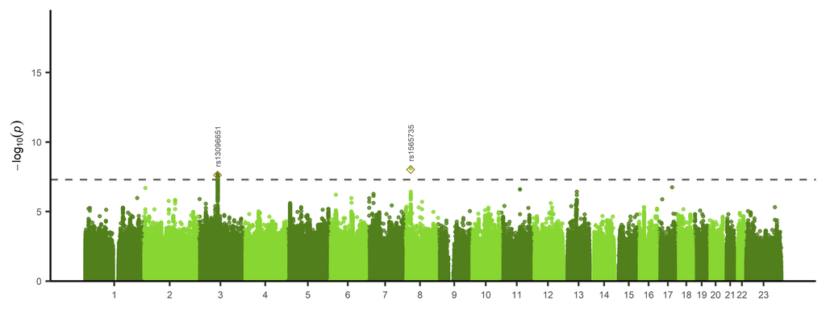

```r
png("metal/FREQ_LIFETIME_manh.png", width=160, height=60, units="mm", res=1000)
ggplot(frq_life_data, aes(x = bp_cum, y = -log10(P), color = as_factor(CHR), size = -log10(P))) +

  geom_hline(yintercept = -log10(sig), color = "grey40", linetype = "dashed", linewidth = 0.5) +

  geom_point(alpha = 0.75, size = 0.5) +
  scale_x_continuous(label = axis_set$CHR, breaks = axis_set$center) +
  scale_y_continuous(expand = c(0,0), limits = c(0, ylim)) +
  scale_color_manual(values = rep(c("#517f1c", "#88d631"), unique(length(axis_set$CHR)))) +
  scale_size_continuous(range = c(0.5,3)) +
  labs(x = NULL,
       y = bquote(-log[10](italic(p)))) +

  theme_classic() +
  theme(
    legend.position = "none",
    panel.grid.major.x = element_blank(),
    panel.grid.minor.x = element_blank(),
    axis.text.x = element_text(vjust = 0.5),
    text = element_text(size = 6.5)
  ) +

  geom_text(data=frq_life_top,
            aes(x=bp_cum, y = -log10(P)),
            label = "\U25C7",
            color="#a6761d",
            size = 3
  ) +

  geom_text(data=frq_life_top,
            aes(x=bp_cum, y = -log10(P) + 0.5, label = SNP),
            color="grey30",
            size = 1.5,
            angle = 90,
            hjust = 0
  )

dev.off()
```

### Maximum frequency

The number of times someone used at the period they used the most.

```r
frq_max <- fread("metal/MA_FREQ_MAX_250919.txt.gz")
frq_max_X <- fread("metal/MA_FREQ_MAX_X_250409.txt")

frq_max <- rbind(frq_max, frq_max_X) %>%
  mutate(CHR = ifelse(CHR == "X", 23, CHR),
         CHR = as.numeric(CHR))

frq_max_cum <- frq_max %>%
  group_by(CHR) %>%
  summarise(max_bp = max(BP)) %>%
  mutate(bp_add = lag(cumsum(as.numeric(max_bp)), default = 0)) %>%
  select(CHR, bp_add)

frq_max_data <- frq_max %>%
  inner_join(frq_max_cum, by = "CHR") %>%
  mutate(bp_cum = BP + bp_add) %>%
  mutate(uniqID = paste(CHR, BP, A1, A2, sep = ":"))

axis_set <- frq_max_data %>%
  group_by(CHR) %>%
  summarize(center = mean(bp_cum))

ylim <- frq_max_data %>%
  filter(P == min(P)) %>%
  mutate(ylim = abs(floor(log10(P))) + 10.5) %>%
  pull(ylim)

sig <- 5e-8



# Clump hits

frq_max_top <- frq_max %>%
  filter(P<5e-8) %>%
  rename(effect_allele = A1) %>%
  rename(other_allele = A2) %>%
  rename(eaf=EAF) %>%
  rename(beta=BETA) %>%
  rename(se=SE) %>%
  rename(pval=P) %>%
  rename(samplesize=N)

fwrite(frq_max_top, "gsem/FREQ_MAX.hits", sep=" ", quote=F, na=NA)
frq_max_top <- read_exposure_data("gsem/FREQ_MAX.hits")
frq_max_top <- clump_data(
  frq_max_top,
  clump_kb = 10000,
  clump_r2 = 0.01,
  bfile = "C:/Users/P018906/OneDrive - Amsterdam UMC/Documents/AMC bridge/1000genomes/1kg.v3/EUR",
  plink_bin = "C:/Users/P018906/AppData/Local/R/win-library/4.3/genetics.binaRies/bin/plink"
)

frq_max_top <- frq_max_top %>%
  select(SNP) %>%
  left_join(frq_max_data)
```

Maximum frequency plot Europeans:

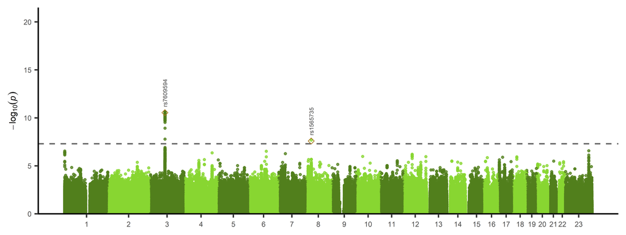

```r
png("metal/FREQ_MAX_manh.png", width=160, height=60, units="mm", res=1000)
ggplot(frq_max_data, aes(x = bp_cum, y = -log10(P), color = as_factor(CHR), size = -log10(P))) +

  geom_hline(yintercept = -log10(sig), color = "grey40", linetype = "dashed", linewidth = 0.5) +

  geom_point(alpha = 0.75, size = 0.5) +
  scale_x_continuous(label = axis_set$CHR, breaks = axis_set$center) +
  scale_y_continuous(expand = c(0,0), limits = c(0, ylim)) +
  scale_color_manual(values = rep(c("#517f1c", "#88d631"), unique(length(axis_set$CHR)))) +
  scale_size_continuous(range = c(0.5,3)) +
  labs(x = NULL,
       y = bquote(-log[10](italic(p)))) +

  theme_classic() +
  theme(
    legend.position = "none",
    panel.grid.major.x = element_blank(),
    panel.grid.minor.x = element_blank(),
    axis.text.x = element_text(vjust = 0.5),
    text = element_text(size = 6.5)
  ) +

  geom_text(data=frq_max_top,
            aes(x=bp_cum, y = -log10(P)),
            label = "\U25C7",
            color="#a6761d",
            size = 3
  ) +

  geom_text(data=frq_max_top,
            aes(x=bp_cum, y = -log10(P) + 0.5, label = SNP),
            color="grey30",
            size = 1.5,
            angle = 90,
            hjust = 0
  )

dev.off()
```

### Recent frequency

How often someone used in the past couple of months/ years.

```r
frq_past <- fread("metal/MA_FREQ_PAST_250919.txt.gz")
frq_past_X <- fread("metal/MA_FREQ_PAST_X_250409.txt")

frq_past <- rbind(frq_past, frq_past_X) %>%
  mutate(CHR = ifelse(CHR == "X", 23, CHR),
         CHR = as.numeric(CHR))

frq_past_cum <- frq_past %>%
  group_by(CHR) %>%
  summarise(max_bp = max(BP)) %>%
  mutate(bp_add = lag(cumsum(as.numeric(max_bp)), default = 0)) %>%
  select(CHR, bp_add)

frq_past_data <- frq_past %>%
  inner_join(frq_past_cum, by = "CHR") %>%
  mutate(bp_cum = BP + bp_add) %>%
  mutate(uniqID = paste(CHR, BP, A1, A2, sep = ":"))

axis_set <- frq_past_data %>%
  group_by(CHR) %>%
  summarize(center = mean(bp_cum))

ylim <- frq_past_data %>%
  filter(P == min(P)) %>%
  mutate(ylim = abs(floor(log10(P))) + 10.5) %>%
  pull(ylim)

sig <- 5e-8
```

Recent frequency plot Europeans:

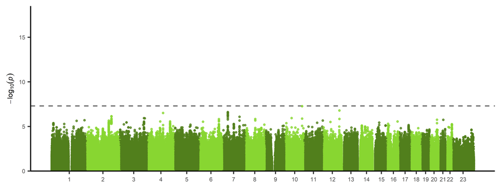

```r
png("metal/FREQ_PAST_manh.png", width=160, height=60, units="mm", res=1000)
ggplot(frq_past_data, aes(x = bp_cum, y = -log10(P), color = as_factor(CHR), size = -log10(P))) +

  geom_hline(yintercept = -log10(sig), color = "grey40", linetype = "dashed", linewidth = 0.5) +

  geom_point(alpha = 0.75, size = 0.5) +
  scale_x_continuous(label = axis_set$CHR, breaks = axis_set$center) +
  scale_y_continuous(expand = c(0,0), limits = c(0, ylim)) +
  scale_color_manual(values = rep(c("#517f1c", "#88d631"), unique(length(axis_set$CHR)))) +
  scale_size_continuous(range = c(0.5,3)) +
  labs(x = NULL,
       y = bquote(-log[10](italic(p)))) +

  theme_classic() +
  theme(
    legend.position = "none",
    panel.grid.major.x = element_blank(),
    panel.grid.minor.x = element_blank(),
    axis.text.x = element_text(vjust = 0.5),
    text = element_text(size = 6.5)
  )

dev.off()
```

## Non-European

We also show the non-European only results, first from the meta-analysis (including AllOfUs and Helius cohorts), then for AllOfUs separately.

### Meta-analysis

```r
CANNABIS_EVR <- fread("metal/MA_CANNABIS_EVR_NONEUR_250704.txt.gz")

CANNABIS_EVR_cum <- CANNABIS_EVR %>%
  mutate(CHR = ifelse(CHR == "X", 23, CHR)) %>%
  mutate(CHR = as.numeric(CHR)) %>%
  group_by(CHR) %>%
  summarise(max_bp = max(BP)) %>%
  mutate(bp_add = lag(cumsum(as.numeric(max_bp)), default = 0)) %>%
  select(CHR, bp_add)

CANNABIS_EVR_data <- CANNABIS_EVR %>%
  mutate(CHR = ifelse(CHR == "X", 23, CHR)) %>%
  mutate(CHR = as.numeric(CHR)) %>%
  inner_join(CANNABIS_EVR_cum, by = "CHR") %>%
  mutate(bp_cum = BP + bp_add) %>%
  mutate(uniqID = paste(CHR, BP, A1, A2, sep = ":"))

axis_set <- CANNABIS_EVR_data %>%
  group_by(CHR) %>%
  summarize(center = mean(bp_cum))

ylim <- CANNABIS_EVR_data %>%
  filter(P == min(P)) %>%
  mutate(ylim = abs(floor(log10(P)))) %>%
  pull(ylim)

ylim <- ylim + 2

sig <- 5e-8

# Use hits clumped with FUMA

CANNABIS_top <- fread("fuma/CANNABIS_EVR_noneur_riskloci.txt")

CANNABIS_top <- CANNABIS_top %>%
  rename(SNP = rsID) %>%
  select(SNP) %>%
  left_join(CANNABIS_EVR_data)

# Add genes mapped positionally with FUMA

CANNABIS_EVR_genes <- fread("fuma/CANNABIS_EVR_noneur_genes.txt")

CANNABIS_EVR_genes_cum <- CANNABIS_EVR_genes %>%
  rename(CHR = chr) %>%
  filter(minGwasP <5e-8) %>%
  mutate(mid = end - ((end - start)/2)) %>%
  left_join(CANNABIS_EVR_cum, by = "CHR") %>%
  mutate(bp_cum = mid + bp_add)

## group loci that are close
threshold <- 10000000

CANNABIS_EVR_genes_top <- CANNABIS_EVR_genes_cum %>%
  group_by(CHR) %>%
  arrange(bp_cum) %>%
  mutate(
    Group = cumsum(ifelse(is.na(lag(bp_cum)) | (bp_cum - lag(bp_cum) > threshold), 1, 0))
  ) %>%
  group_by(CHR, Group) %>%
  arrange(minGwasP, .by_group = T) %>%
  slice(1) %>%
  ungroup()

# make some lines for exact gene position

dashedlines <- CANNABIS_EVR_genes_cum %>%
  select(bp_cum)

x_coordinates <- eval(parse(text = as.character(dashedlines)))
```

Ever use plot non-Europeans:

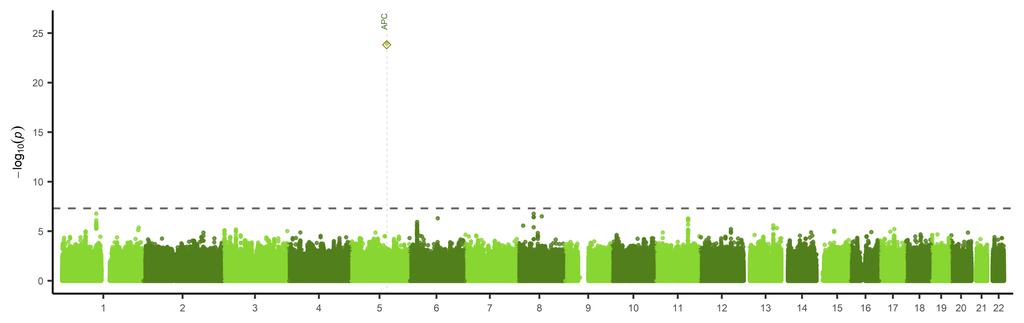

```r
png("metal/CANNABIS_EVR_noneur_manh.png", width=190, height=60, units="mm", res=1000)

ggplot(CANNABIS_EVR_data, aes(x = bp_cum, y = -log10(P), color = as_factor(CHR), size = -log10(P))) +

  geom_hline(yintercept = -log10(sig), color = "grey40", linetype = "dashed", linewidth = 0.5) +
  geom_vline(xintercept = x_coordinates, linetype = "dashed", color = "lightgrey", linewidth = 0.2) +

  geom_point(alpha = 0.75, size = 0.5) +
  scale_x_continuous(label = axis_set$CHR,
                     breaks = axis_set$center,
                     expand = expansion(mult = c(0.01, 0.01))) +
  coord_cartesian(ylim = c(0, ylim),
                  clip = "off") +
  scale_y_continuous(
    breaks = pretty(c(ylim, 0)),
    labels = function(b) abs(b)
  ) +
  scale_color_manual(values = rep(c("#88d631", "#517f1c"), unique(length(axis_set$CHR)))) +
  scale_size_continuous(range = c(0.5,3)) +
  labs(x = NULL,
       y = bquote(-log[10](italic(p)))) +

  theme_classic() +
  theme(
    legend.position = "none",
    panel.grid.major.x = element_blank(),
    panel.grid.minor.x = element_blank(),
    axis.text.x = element_text(vjust = 0.5),
    text = element_text(size = 6.5)
  ) +

  geom_text(data=CANNABIS_top,
            aes(x=bp_cum, y = -log10(P)),
            label = "\U25C7",
            # label = "\U0001F341",
            color="#a6761d",
            size = 3
  ) +

  geom_text(
    data = CANNABIS_EVR_genes_top,
    aes(x = bp_cum, y = ylim + 1, label = symbol),
    color = "#476f19",
    size = 1.5,
    angle = 90,
    vjust = 0,
    hjust = 1
  )

dev.off()
```

### AllOfUs

Because there were hits for both ever use and frequency for the non-European analysis in AllOfUs (from GENESIS), we present these results separately.

#### Ever use

First, data are prepared for the AllOfUs results from GENESIS for ever use.

```r
CANNABIS_EVR <- fread("genesis/ALLOFUS.NONEUR.CANNABIS_EVR.EZQC.txt.gz")

CANNABIS_EVR_cum <- CANNABIS_EVR %>%
  rename(BP = POS, A1 = EFFECT_ALLELE, A2 = OTHER_ALLELE, P = PVAL) %>%
  mutate(CHR = ifelse(CHR == "X", 23, CHR)) %>%
  mutate(CHR = as.numeric(CHR)) %>%
  group_by(CHR) %>%
  summarise(max_bp = max(BP)) %>%
  mutate(bp_add = lag(cumsum(as.numeric(max_bp)), default = 0)) %>%
  select(CHR, bp_add)

CANNABIS_EVR_data <- CANNABIS_EVR %>%
  rename(BP = POS, A1 = EFFECT_ALLELE, A2 = OTHER_ALLELE, P = PVAL) %>%
  mutate(CHR = ifelse(CHR == "X", 23, CHR)) %>%
  mutate(CHR = as.numeric(CHR)) %>%
  inner_join(CANNABIS_EVR_cum, by = "CHR") %>%
  mutate(bp_cum = BP + bp_add) %>%
  mutate(uniqID = paste(CHR, BP, A1, A2, sep = ":"))

axis_set <- CANNABIS_EVR_data %>%
  group_by(CHR) %>%
  summarize(center = mean(bp_cum))

ylim <- CANNABIS_EVR_data %>%
  filter(P == min(P)) %>%
  mutate(ylim = abs(floor(log10(P))) + 10.5) %>%
  pull(ylim)

sig <- 5e-8

# Use hits clumped with FUMA

CANNABIS_top <- fread("fuma/CANNABIS_EVR_noneur_AllOfUs_riskloci.txt")

CANNABIS_top <- CANNABIS_top %>%
  rename(SNP = rsID) %>%
  select(SNP) %>%
  left_join(CANNABIS_EVR_data)

CANNABIS_top_nonoverlapping <- CANNABIS_top %>%
  arrange(P) %>%
  group_by(CHR) %>%
  do({
    snps <- .
    kept <- c()
    for (i in seq_len(nrow(snps))) {
      pos <- snps$bp_cum[i]
      if (all(abs(pos - snps$bp_cum[kept]) > 15000000)) {
        kept <- c(kept, i)
      }
    }
    snps[kept, ]
  }) %>%
  ungroup()

# Add genes mapped positionally with FUMA

CANNABIS_EVR_genes <- fread("fuma/CANNABIS_EVR_noneur_AllOfUs_genes.txt")

CANNABIS_EVR_genes_cum <- CANNABIS_EVR_genes %>%
  rename(CHR = chr) %>%
  filter(minGwasP <5e-8) %>%
  mutate(mid = end - ((end - start)/2)) %>%
  left_join(CANNABIS_EVR_cum, by = "CHR") %>%
  mutate(bp_cum = mid + bp_add)

## group loci that are close
threshold <- 10000000

CANNABIS_EVR_genes_top <- CANNABIS_EVR_genes_cum %>%
  group_by(CHR) %>%
  arrange(bp_cum) %>%
  mutate(
    Group = cumsum(ifelse(is.na(lag(bp_cum)) | (bp_cum - lag(bp_cum) > threshold), 1, 0))
  ) %>%
  group_by(CHR, Group) %>%
  arrange(minGwasP, .by_group = T) %>%
  slice(1) %>%
  ungroup()

# make some lines for exact gene position

dashedlines <- CANNABIS_EVR_genes_cum %>%
  select(bp_cum)

x_coordinates <- eval(parse(text = as.character(dashedlines)))

# The PELP1 is still a bit too close to TOM1L2, so add that one separately

CANNABIS_EVR_genes_TOM1L2 <- CANNABIS_EVR_genes_top %>% filter(symbol == "TOM1L2")
CANNABIS_EVR_genes_top <- CANNABIS_EVR_genes_top %>% filter(symbol != "TOM1L2")
```

Ever use plot non-Europeans from the AllOfUs sample:

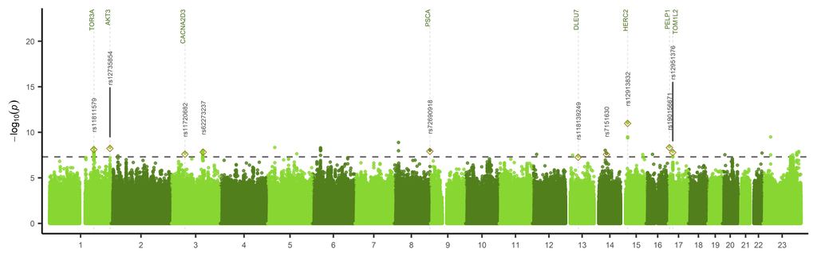

```r
png("genesis/CANNABIS_EVR_noneur_AllOfUs_manh.png", width=190, height=60, units="mm", res=1000)

ggplot(CANNABIS_EVR_data, aes(x = bp_cum, y = -log10(P), color = as_factor(CHR), size = -log10(P))) +

  geom_hline(yintercept = -log10(sig), color = "grey40", linetype = "dashed", linewidth = 0.5) +
  geom_vline(xintercept = x_coordinates, linetype = "dashed", color = "lightgrey", linewidth = 0.2) +

  geom_point(alpha = 0.75, size = 0.5) +
  scale_x_continuous(label = axis_set$CHR,
                     breaks = axis_set$center,
                     expand = expansion(mult = c(0.01, 0.01))) +
  coord_cartesian(ylim = c(0, ylim),
                  clip = "off") +
  scale_y_continuous(
    breaks = pretty(c(ylim, 0)),
    labels = function(b) abs(b)
  ) +
  scale_color_manual(values = rep(c("#88d631", "#517f1c"), unique(length(axis_set$CHR)))) +
  scale_size_continuous(range = c(0.5,3)) +
  labs(x = NULL,
       y = bquote(-log[10](italic(p)))) +

  theme_classic() +
  theme(
    legend.position = "none",
    panel.grid.major.x = element_blank(),
    panel.grid.minor.x = element_blank(),
    axis.text.x = element_text(vjust = 0.5),
    text = element_text(size = 6.5)
  ) +

  geom_text(data=CANNABIS_top,
            aes(x=bp_cum, y = -log10(P)),
            label = "\U25C7",
            # label = "\U0001F341",
            color="#a6761d",
            size = 3
  ) +

  geom_text_repel(
    data = CANNABIS_top,
    aes(x = bp_cum, y = -log10(P) + 1, label = SNP),
    color = "grey30",
    size = 1.5,
    angle = 90,
    direction = "y",
    hjust = 0,
    box.padding = 0.3,
    point.padding = 0.3,
    force = 2,
    max.overlaps = Inf
  ) +

  geom_text(
    data = CANNABIS_EVR_genes_top,
    aes(x = bp_cum, y = ylim + 1, label = symbol),
    color = "#476f19",
    size = 1.5,
    angle = 90,
    vjust = 0,
    hjust = 1
  ) +

  geom_text(
    data = CANNABIS_EVR_genes_TOM1L2,
    aes(x = bp_cum, y = ylim + 1, label = symbol),
    color = "#476f19",
    size = 1.5,
    angle = 90,
    vjust = 1,
    hjust = 1
  )

dev.off()
```

#### Recent frequency

AllOfUs also had a measure of recent frequency.

```r
FREQ_PAST <- fread("genesis/AllOfUs_v8_NonEUR_FREQ_PAST_formatted.csv.gz")

FREQ_PAST_cum <- FREQ_PAST %>%
  rename(BP = POS) %>%
  mutate(CHR = ifelse(CHR == "X", 23, CHR)) %>%
  mutate(CHR = as.numeric(CHR)) %>%
  group_by(CHR) %>%
  summarise(max_bp = max(BP)) %>%
  mutate(bp_add = lag(cumsum(as.numeric(max_bp)), default = 0)) %>%
  select(CHR, bp_add)

FREQ_PAST_data <- FREQ_PAST %>%
  rename(BP = POS) %>%
  mutate(CHR = ifelse(CHR == "X", 23, CHR)) %>%
  mutate(CHR = as.numeric(CHR)) %>%
  inner_join(FREQ_PAST_cum, by = "CHR") %>%
  mutate(bp_cum = BP + bp_add) %>%
  mutate(uniqID = paste(CHR, BP, A1, A2, sep = ":"))

axis_set <- FREQ_PAST_data %>%
  group_by(CHR) %>%
  summarize(center = mean(bp_cum))

ylim <- CANNABIS_EVR_data %>%
  filter(P == min(P)) %>%
  mutate(ylim = abs(floor(log10(P))) + 10.5) %>%
  pull(ylim)

sig <- 5e-8


# Use hits clumped with FUMA

FREQ_PAST_top <- fread("fuma/FREQ_PAST_noneur_AllOfUs_riskloci.txt")

FREQ_PAST_top <- FREQ_PAST_top %>%
  rename(SNP = rsID) %>%
  select(SNP) %>%
  left_join(FREQ_PAST_data)

FREQ_PAST_top_nonoverlapping <- CANNABIS_top %>%
  arrange(P) %>%
  group_by(CHR) %>%
  do({
    snps <- .
    kept <- c()
    for (i in seq_len(nrow(snps))) {
      pos <- snps$bp_cum[i]
      if (all(abs(pos - snps$bp_cum[kept]) > 15000000)) {
        kept <- c(kept, i)
      }
    }
    snps[kept, ]
  }) %>%
  ungroup()

# Add genes mapped positionally with FUMA

FREQ_PAST_genes <- fread("fuma/FREQ_PAST_noneur_AllOfUs_genes.txt")

FREQ_PAST_genes_cum <- FREQ_PAST_genes %>%
  rename(CHR = chr) %>%
  filter(minGwasP <5e-8) %>%
  mutate(mid = end - ((end - start)/2)) %>%
  left_join(CANNABIS_EVR_cum, by = "CHR") %>%
  mutate(bp_cum = mid + bp_add)

## group loci that are close
threshold <- 10000000

FREQ_PAST_genes_top <- FREQ_PAST_genes_cum %>%
  group_by(CHR) %>%
  arrange(bp_cum) %>%
  mutate(
    Group = cumsum(ifelse(is.na(lag(bp_cum)) | (bp_cum - lag(bp_cum) > threshold), 1, 0))
  ) %>%
  group_by(CHR, Group) %>%
  arrange(minGwasP, .by_group = T) %>%
  slice(1) %>%
  ungroup()

# make some lines for exact gene position

dashedlines <- CANNABIS_EVR_genes_cum %>%
  select(bp_cum)

x_coordinates <- eval(parse(text = as.character(dashedlines)))
```

Recent frequency plot non-Europeans from the AllOfUs sample:

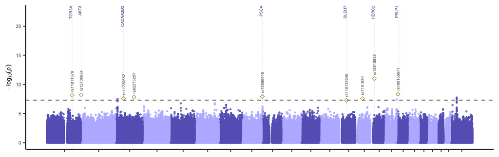

```r
png("genesis/FREQ_PAST_noneur_AllOfUs_manh.png", width=190, height=60, units="mm", res=1000)
ggplot(FREQ_PAST_data, aes(x = bp_cum, y = -log10(P), color = as_factor(CHR), size = -log10(P))) +

  geom_hline(yintercept = -log10(sig), color = "grey40", linetype = "dashed", linewidth = 0.5) +
  geom_vline(xintercept = x_coordinates, linetype = "dashed", color = "lightgrey", linewidth = 0.2) +
  geom_point(alpha = 0.75, size = 0.5) +
  scale_x_continuous(label = axis_set$CHR, breaks = axis_set$center) +
  coord_cartesian(ylim = c(0, ylim),
                  clip = "off") +
  scale_y_continuous(
    breaks = pretty(c(0, ylim)),
    labels = function(b) abs(b)
  ) +
  scale_color_manual(values = rep(c("#544cb2", "#aea7ff"), unique(length(axis_set$CHR)))) +
  scale_size_continuous(range = c(-0.5,-3)) +
  labs(x = NULL,
       y = bquote(-log[10](italic(p)))) +

  theme_classic() +
  theme(
    legend.position = "none",
    panel.grid.major.x = element_blank(),
    panel.grid.minor.x = element_blank(),
    axis.text.x = element_blank(),
    text = element_text(size = 6.5)
  ) +

  geom_text(data=FREQ_PAST_top_nonoverlapping,
            aes(x=bp_cum, y = -log10(P)),
            label = "\U25C7",
            # label = "\U0001F341",
            color="#a6761d",
            size = 3
  ) +

  geom_text(data=FREQ_PAST_top_nonoverlapping,
            aes(x=bp_cum, y = -log10(P) + 0.5, label = SNP),
            color="grey30",
            size = 1.5,
            angle = 90,
            hjust = 0
  ) +

  geom_text(
    data = CANNABIS_EVR_genes_top,
    aes(x = bp_cum, y = ylim + 1, label = symbol),
    color = "#383278",
    size = 1.5,
    angle = 90,
    vjust = 0,
    hjust = 1
  )
dev.off()
```